# Data analysis Morphological masked priming experiment on L1-ITA, L2-ENG bilingual speakers/readers

```r
aoaglmer2.anova <- car::Anova(aoaglmer2)
aoaglmer2c.anova <- car::Anova(aoaglmer2c)
aoaglmer2.modelsum <- summary(aoaglmer2)
aoaglmer2c.modelsum <- summary(aoaglmer2c)
```

Anova of aoaglmer2 - or contrast

```r
aoaglmer2.anova
```

```
## Analysis of Deviance Table (Type II Wald chisquare tests)
##
## Response: rt
##                                     Chisq Df Pr(>Chisq)
## relatedness                      221.0385  1  < 2.2e-16 ***
## morphType                          0.8731  2   0.646273
## aoa2.usage                         0.2344  1   0.628264
## freqTarget                       594.1524  1  < 2.2e-16 ***
## relatedness:morphType              9.5127  2   0.008597 **
## relatedness:aoa2.usage            19.1904  1  1.183e-05 ***
## morphType:aoa2.usage              12.4446  2   0.001985 **
## relatedness:morphType:aoa2.usage  19.8405  2  4.917e-05 ***
## ---
## Signif. codes:  0 '***' 0.001 '**' 0.01 '*' 0.05 '.' 0.1 ' ' 1
```

```r
knitr::kable(round(aoaglmer2.modelsum$coefficients, 4))
```

|  | Estimate | Std. Error | t value | Pr(>\|z\|) |
| --- | --- | --- | --- | --- |
| (Intercept) | 1008.8140 | 4.3403 | 232.4319 | 0.0000 |
| relatednessrel | -51.5715 | 3.7709 | -13.6762 | 0.0000 |
| morphTypeop | 1.8958 | 3.3523 | 0.5655 | 0.5717 |
| morphTypetr | 5.9059 | 4.6465 | 1.2710 | 0.2037 |
| aoa2.usage | 2.8479 | 3.3890 | 0.8404 | 0.4007 |
| freqTarget | -69.2448 | 2.8408 | -24.3752 | 0.0000 |
| relatednessrel:morphTypeop | 10.2784 | 3.4085 | 3.0155 | 0.0026 |
| relatednessrel:morphTypetr | 6.5114 | 3.9510 | 1.6480 | 0.0993 |
| relatednessrel:aoa2.usage | 10.3616 | 1.7518 | 5.9149 | 0.0000 |
| morphTypeop:aoa2.usage | -2.1007 | 2.5761 | -0.8155 | 0.4148 |
| morphTypetr:aoa2.usage | -4.9514 | 2.1994 | -2.2512 | 0.0244 |
| relatednessrel:morphTypeop:aoa2.usage | -5.0028 | 2.0351 | -2.4582 | 0.0140 |
| relatednessrel:morphTypetr:aoa2.usage | -7.5540 | 1.8106 | -4.1721 | 0.0000 |

Anova of aoaglmer2c - op contrast

```r
aoaglmer2c.anova
```

```
## Analysis of Deviance Table (Type II Wald chisquare tests)
##
## Response: rt
##                                     Chisq Df Pr(>Chisq)
## relatedness                      204.6584  1  < 2.2e-16 ***
## morphType                          0.2466  2    0.88401
## aoa2.usage                         0.0949  1    0.75803
## freqTarget                       531.4092  1  < 2.2e-16 ***
## relatedness:morphType              6.2196  2    0.04461 *
## relatedness:aoa2.usage            20.5887  1  5.693e-06 ***
## morphType:aoa2.usage              11.1510  2    0.00379 **
## relatedness:morphType:aoa2.usage  10.6047  2    0.00498 **
## ---
## Signif. codes:  0 '***' 0.001 '**' 0.01 '*' 0.05 '.' 0.1 ' ' 1
```

```r
knitr::kable(round(aoaglmer2c.modelsum$coefficients, 4))
```

|  | Estimate | Std. Error | t value | Pr(>\|z\|) |
| --- | --- | --- | --- | --- |
| (Intercept) | 1010.6973 | 3.2757 | 308.5464 | 0.0000 |
| relatednessrel | -41.2928 | 3.4545 | -11.9532 | 0.0000 |
| morphTypeor | -1.8942 | 3.0906 | -0.6129 | 0.5400 |
| morphTypetr | 4.0100 | 4.1432 | 0.9678 | 0.3331 |
| aoa2.usage | 0.7503 | 2.9865 | 0.2512 | 0.8016 |
| freqTarget | -69.2444 | 3.0038 | -23.0523 | 0.0000 |
| relatednessrel:morphTypeor | -10.2732 | 4.0885 | -2.5127 | 0.0120 |
| relatednessrel:morphTypetr | -3.7669 | 3.3324 | -1.1304 | 0.2583 |
| relatednessrel:aoa2.usage | 5.3587 | 1.4626 | 3.6637 | 0.0002 |
| morphTypeor:aoa2.usage | 2.1010 | 2.3084 | 0.9102 | 0.3627 |
| morphTypetr:aoa2.usage | -2.8509 | 2.1377 | -1.3336 | 0.1823 |
| relatednessrel:morphTypeor:aoa2.usage | 5.0014 | 2.0999 | 2.3818 | 0.0172 |
| relatednessrel:morphTypetr:aoa2.usage | -2.5512 | 1.8387 | -1.3875 | 0.1653 |

```r
aoaglmer3.anova <- car::Anova(aoaglmer3)
aoaglmer3c.anova <- car::Anova(aoaglmer3c)
aoaglmer3.modelsum <- summary(aoaglmer3)
aoaglmer3c.modelsum <- summary(aoaglmer3c)
```

Anova of aoaglmer3 - or contrast

```r
aoaglmer3.anova
```

```
## Analysis of Deviance Table (Type II Wald chisquare tests)
##
## Response: rt
##                                       Chisq Df Pr(>Chisq)
## relatedness                        112.2561  1  < 2.2e-16 ***
## morphType                           58.1050  2  2.414e-13 ***
## aoa3.context                         5.6946  1  0.0170176 *
## freqTarget                         554.3539  1  < 2.2e-16 ***
## relatedness:morphType               17.3889  2  0.0001675 ***
## relatedness:aoa3.context             1.6211  1  0.2029450
## morphType:aoa3.context              53.9894  2  1.889e-12 ***
## relatedness:morphType:aoa3.context  12.7531  2  0.0017010 **
## ---
## Signif. codes:  0 '***' 0.001 '**' 0.01 '*' 0.05 '.' 0.1 ' ' 1
```

```r
knitr::kable(round(aoaglmer3.modelsum$coefficients, 4))
```

|  | Estimate | Std. Error | t value | Pr(>\|z\|) |
| --- | --- | --- | --- | --- |
| (Intercept) | 1010.3281 | 4.0408 | 250.0303 | 0.0000 |
| relatednessrel | -15.7640 | 2.5784 | -6.1139 | 0.0000 |
| morphTypeop | -20.2492 | 4.6900 | -4.3175 | 0.0000 |
| morphTypetr | -29.6723 | 5.4359 | -5.4586 | 0.0000 |
| aoa3.contextschool | 8.6139 | 4.0124 | 2.1468 | 0.0318 |
| freqTarget | -69.3765 | 2.9466 | -23.5447 | 0.0000 |
| relatednessrel:morphTypeop | -7.8865 | 3.5802 | -2.2028 | 0.0276 |
| relatednessrel:morphTypetr | -9.4440 | 2.9994 | -3.1487 | 0.0016 |
| relatednessrel:aoa3.contextschool | -3.7625 | 2.9816 | -1.2619 | 0.2070 |
| morphTypeop:aoa3.contextschool | 18.1619 | 3.4790 | 5.2204 | 0.0000 |
| morphTypetr:aoa3.contextschool | 23.2368 | 3.8477 | 6.0391 | 0.0000 |
| relatednessrel:morphTypeop:aoa3.contextschool | 2.6407 | 2.7957 | 0.9446 | 0.3449 |
| relatednessrel:morphTypetr:aoa3.contextschool | -8.9994 | 2.6306 | -3.4211 | 0.0006 |

Anova of aoaglmer3c - op contrast

```r
aoaglmer3c.anova
```

```
## Analysis of Deviance Table (Type II Wald chisquare tests)
##
## Response: rt
##                                       Chisq Df Pr(>Chisq)
## relatedness                        124.8011  1  < 2.2e-16 ***
## morphType                           45.5467  2  1.287e-10 ***
## aoa3.context                        48.2869  1  3.682e-12 ***
## freqTarget                         481.4402  1  < 2.2e-16 ***
## relatedness:morphType                6.4028  2  0.0407056 *
## relatedness:aoa3.context             0.8070  1  0.3690075
## morphType:aoa3.context              16.9403  2  0.0002096 ***
## relatedness:morphType:aoa3.context   8.0212  2  0.0181227 *
## ---
## Signif. codes:  0 '***' 0.001 '**' 0.01 '*' 0.05 '.' 0.1 ' ' 1
```

```r
knitr::kable(round(aoaglmer3c.modelsum$coefficients, 4))
```

|  | Estimate | Std. Error | t value | Pr(>\|z\|) |
| --- | --- | --- | --- | --- |
| (Intercept) | 990.0474 | 11.1235 | 89.0047 | 0.0000 |
| relatednessrel | -23.6486 | 3.1099 | -7.6043 | 0.0000 |
| morphTypeor | 20.2524 | 3.7346 | 5.4229 | 0.0000 |
| morphTypetr | -9.4203 | 4.7280 | -1.9925 | 0.0463 |
| aoa3.contextschool | 26.8035 | 3.6248 | 7.3945 | 0.0000 |
| freqTarget | -69.3751 | 3.1618 | -21.9417 | 0.0000 |
| relatednessrel:morphTypeor | 7.8848 | 4.1938 | 1.8801 | 0.0601 |
| relatednessrel:morphTypetr | -1.5600 | 3.5857 | -0.4351 | 0.6635 |
| relatednessrel:aoa3.contextschool | -1.1238 | 3.6388 | -0.3088 | 0.7575 |
| morphTypeor:aoa3.contextschool | -18.1640 | 4.5644 | -3.9795 | 0.0001 |
| morphTypetr:aoa3.contextschool | 5.0720 | 3.9001 | 1.3005 | 0.1934 |
| relatednessrel:morphTypeor:aoa3.contextschool | -2.6390 | 5.9862 | -0.4408 | 0.6593 |
| relatednessrel:morphTypetr:aoa3.contextschool | -11.6374 | 4.1993 | -2.7713 | 0.0056 |

```r
aoaglmer4.anova <- car::Anova(aoaglmer4)
aoaglmer4c.anova <- car::Anova(aoaglmer4c)
aoaglmer4.modelsum <- summary(aoaglmer4)
aoaglmer4c.modelsum <- summary(aoaglmer4c)
```

Anova of aoaglmer4 - or contrast

```r
aoaglmer4.anova
```

```
## Analysis of Deviance Table (Type II Wald chisquare tests)
##
## Response: rt
##                                              Chisq Df Pr(>Chisq)
## relatedness                                138.033  1  < 2.2e-16 ***
## morphType                                   11.109  2  0.0038704 **
## aoa4.contextMultling                        13.357  1  0.0002575 ***
## freqTarget                                 487.766  1  < 2.2e-16 ***
## relatedness:morphType                       34.899  2  2.641e-08 ***
## relatedness:aoa4.contextMultling            16.465  1  4.955e-05 ***
## morphType:aoa4.contextMultling              37.648  2  6.680e-09 ***
## relatedness:morphType:aoa4.contextMultling  89.579  2  < 2.2e-16 ***
## ---
## Signif. codes:  0 '***' 0.001 '**' 0.01 '*' 0.05 '.' 0.1 ' ' 1
```

```r
knitr::kable(round(aoaglmer4.modelsum$coefficients, 4))
```

|  | Estimate | Std. Error | t value | Pr(>\|z\|) |
| --- | --- | --- | --- | --- |
| (Intercept) | 1014.8046 | 5.7263 | 177.2179 | 0.0000 |
| relatednessrel | -16.0639 | 2.6856 | -5.9814 | 0.0000 |
| morphTypeop | -0.1632 | 3.9786 | -0.0410 | 0.9673 |
| morphTypetr | -7.7779 | 4.5384 | -1.7138 | 0.0866 |
| aoa4.contextMultlingyes | 14.7674 | 3.3393 | 4.4224 | 0.0000 |
| freqTarget | -69.3824 | 3.1415 | -22.0854 | 0.0000 |
| relatednessrel:morphTypeop | -14.2395 | 3.0575 | -4.6573 | 0.0000 |
| relatednessrel:morphTypetr | -19.4036 | 3.5524 | -5.4621 | 0.0000 |
| relatednessrel:aoa4.contextMultlingyes | -12.5803 | 3.0768 | -4.0887 | 0.0000 |
| morphTypeop:aoa4.contextMultlingyes | -19.0786 | 3.5764 | -5.3346 | 0.0000 |
| morphTypetr:aoa4.contextMultlingyes | -8.9828 | 3.4055 | -2.6378 | 0.0083 |
| relatednessrel:morphTypeop:aoa4.contextMultlingyes | 37.3186 | 4.0395 | 9.2383 | 0.0000 |
| relatednessrel:morphTypetr:aoa4.contextMultlingyes | 9.3316 | 4.3502 | 2.1451 | 0.0319 |

Anova of aoaglmer4c - op contrast

```r
aoaglmer4c.anova
```

```
## Analysis of Deviance Table (Type II Wald chisquare tests)
##
## Response: rt
##                                               Chisq Df Pr(>Chisq)
## relatedness                                118.4592  1  < 2.2e-16 ***
## morphType                                    8.0640  2  0.0177388 *
## aoa4.contextMultling                         0.0178  1  0.8938698
## freqTarget                                 381.5908  1  < 2.2e-16 ***
## relatedness:morphType                       21.4154  2  2.237e-05 ***
## relatedness:aoa4.contextMultling            12.8175  1  0.0003434 ***
## morphType:aoa4.contextMultling              67.6195  2  2.073e-15 ***
## relatedness:morphType:aoa4.contextMultling 112.2455  2  < 2.2e-16 ***
## ---
## Signif. codes:  0 '***' 0.001 '**' 0.01 '*' 0.05 '.' 0.1 ' ' 1
```

```r
knitr::kable(round(aoaglmer4c.modelsum$coefficients, 4))
```

|  | Estimate | Std. Error | t value | Pr(>\|z\|) |
| --- | --- | --- | --- | --- |
| (Intercept) | 1014.6335 | 3.7310 | 271.9502 | 0.0000 |
| relatednessrel | -30.3036 | 2.6323 | -11.5120 | 0.0000 |
| morphTypeor | 0.1644 | 3.5029 | 0.0469 | 0.9626 |
| morphTypetr | -7.6135 | 3.6554 | -2.0828 | 0.0373 |
| aoa4.contextMultlingyes | -4.3090 | 4.1699 | -1.0333 | 0.3014 |
| freqTarget | -69.3810 | 3.5517 | -19.5343 | 0.0000 |
| relatednessrel:morphTypeor | 14.2400 | 2.9286 | 4.8624 | 0.0000 |
| relatednessrel:morphTypetr | -5.1641 | 4.0898 | -1.2627 | 0.2067 |
| relatednessrel:aoa4.contextMultlingyes | 24.7394 | 3.6402 | 6.7962 | 0.0000 |
| morphTypeor:aoa4.contextMultlingyes | 19.0799 | 3.5817 | 5.3270 | 0.0000 |
| morphTypetr:aoa4.contextMultlingyes | 10.0963 | 3.3269 | 3.0347 | 0.0024 |
| relatednessrel:morphTypeor:aoa4.contextMultlingyes | -37.3209 | 4.4065 | -8.4695 | 0.0000 |
| relatednessrel:morphTypetr:aoa4.contextMultlingyes | -27.9879 | 4.0259 | -6.9520 | 0.0000 |

```r
aoaglmer5.anova <- car::Anova(aoaglmer5)
aoaglmer5c.anova <- car::Anova(aoaglmer5c)
aoaglmer5.modelsum <- summary(aoaglmer5)
aoaglmer5c.modelsum <- summary(aoaglmer5c)
```

Anova of aoaglmer5 - or contrast

```r
aoaglmer5.anova
```

```
## Analysis of Deviance Table (Type II Wald chisquare tests)
##
## Response: rt
##                                             Chisq Df Pr(>Chisq)
## relatedness                              208.3417  1  < 2.2e-16 ***
## morphType                                  7.5328  2   0.023135 *
## aoa5.selfRatedProf                         7.0812  1   0.007790 **
## freqTarget                               371.8232  1  < 2.2e-16 ***
## lengthTarget                              78.5755  1  < 2.2e-16 ***
## relatedness:morphType                    126.4083  2  < 2.2e-16 ***
## relatedness:aoa5.selfRatedProf            30.3694  1  3.571e-08 ***
## morphType:aoa5.selfRatedProf              10.1555  2   0.006234 **
## relatedness:morphType:aoa5.selfRatedProf  68.0810  2  1.646e-15 ***
## ---
## Signif. codes:  0 '***' 0.001 '**' 0.01 '*' 0.05 '.' 0.1 ' ' 1
```

```r
knitr::kable(round(aoaglmer5.modelsum$coefficients, 4))
```

|  | Estimate | Std. Error | t value | Pr(>\|z\|) |
| --- | --- | --- | --- | --- |
| (Intercept) | 1190.5452 | 6.3788 | 186.6397 | 0.0000 |
| relatednessrel | -70.9797 | 5.0746 | -13.9872 | 0.0000 |
| morphTypeop | 15.0837 | 3.9889 | 3.7814 | 0.0002 |
| morphTypetr | 8.5210 | 3.9509 | 2.1568 | 0.0310 |
| aoa5.selfRatedProf | -12.1673 | 4.3049 | -2.8264 | 0.0047 |
| freqTarget | -72.1470 | 3.7415 | -19.2827 | 0.0000 |
| lengthTarget | -26.5652 | 2.9969 | -8.8643 | 0.0000 |
| relatednessrel:morphTypeop | 41.7713 | 3.9409 | 10.5995 | 0.0000 |
| relatednessrel:morphTypetr | 31.2858 | 4.0719 | 7.6834 | 0.0000 |
| relatednessrel:aoa5.selfRatedProf | 14.7631 | 1.7101 | 8.6330 | 0.0000 |
| morphTypeop:aoa5.selfRatedProf | -4.1976 | 2.7160 | -1.5455 | 0.1222 |
| morphTypetr:aoa5.selfRatedProf | -2.5407 | 2.3469 | -1.0826 | 0.2790 |
| relatednessrel:morphTypeop:aoa5.selfRatedProf | -13.4543 | 2.0818 | -6.4629 | 0.0000 |
| relatednessrel:morphTypetr:aoa5.selfRatedProf | -13.7726 | 1.9811 | -6.9521 | 0.0000 |

Anova of aoaglmer5c - op contrast

```r
aoaglmer5c.anova
```

```
## Analysis of Deviance Table (Type II Wald chisquare tests)
##
## Response: rt
##                                            Chisq Df Pr(>Chisq)
## relatedness                              178.378  1  < 2.2e-16 ***
## morphType                                 15.949  2  0.0003442 ***
## aoa5.selfRatedProf                        18.979  1  1.321e-05 ***
## freqTarget                               551.733  1  < 2.2e-16 ***
## relatedness:morphType                    107.112  2  < 2.2e-16 ***
## relatedness:aoa5.selfRatedProf            16.315  1  5.363e-05 ***
## morphType:aoa5.selfRatedProf              12.829  2  0.0016376 **
## relatedness:morphType:aoa5.selfRatedProf  57.396  2  3.441e-13 ***
## ---
## Signif. codes:  0 '***' 0.001 '**' 0.01 '*' 0.05 '.' 0.1 ' ' 1
```

```r
knitr::kable(round(aoaglmer5c.modelsum$coefficients, 4))
```

|  | Estimate | Std. Error | t value | Pr(>\|z\|) |
| --- | --- | --- | --- | --- |
| (Intercept) | 1069.7679 | 4.3337 | 246.8492 | 0.0000 |
| relatednessrel | -28.9715 | 2.9596 | -9.7891 | 0.0000 |
| morphTypeor | -10.2669 | 4.1874 | -2.4519 | 0.0142 |
| morphTypetr | -10.9334 | 4.1105 | -2.6599 | 0.0078 |
| aoa5.selfRatedProf | -16.3513 | 3.6982 | -4.4214 | 0.0000 |
| freqTarget | -69.2447 | 2.9480 | -23.4890 | 0.0000 |
| relatednessrel:morphTypeor | -41.7143 | 3.5639 | -11.7047 | 0.0000 |
| relatednessrel:morphTypetr | -10.5767 | 3.8383 | -2.7556 | 0.0059 |
| relatednessrel:aoa5.selfRatedProf | 1.2412 | 1.3897 | 0.8932 | 0.3718 |
| morphTypeor:aoa5.selfRatedProf | 4.2182 | 2.6033 | 1.6203 | 0.1052 |
| morphTypetr:aoa5.selfRatedProf | 1.6447 | 2.3242 | 0.7076 | 0.4792 |
| relatednessrel:morphTypeor:aoa5.selfRatedProf | 13.4287 | 1.8466 | 7.2723 | 0.0000 |
| relatednessrel:morphTypetr:aoa5.selfRatedProf | -0.3072 | 1.8570 | -0.1654 | 0.8686 |

```r
aoaglmer6.anova <- car::Anova(aoaglmer6)
aoaglmer6c.anova <- car::Anova(aoaglmer6c)
aoaglmer6.modelsum <- summary(aoaglmer6)
aoaglmer6c.modelsum <- summary(aoaglmer6c)
```

Anova of aoaglmer6 - or contrast

```r
aoaglmer6.anova
```

```
## Analysis of Deviance Table (Type II Wald chisquare tests)
##
## Response: rt
##                                         Chisq Df Pr(>Chisq)
## relatedness                           94.3669  1  < 2.2e-16 ***
## morphType                              6.1065  2    0.04721 *
## aoa6.otherLang                        24.5541  1  7.225e-07 ***
## freqTarget                           492.3427  1  < 2.2e-16 ***
## relatedness:morphType                 54.5036  2  1.461e-12 ***
## relatedness:aoa6.otherLang             3.1366  1    0.07656 .
## morphType:aoa6.otherLang               1.0621  2    0.58797
## relatedness:morphType:aoa6.otherLang  25.4509  2  2.974e-06 ***
## ---
## Signif. codes:  0 '***' 0.001 '**' 0.01 '*' 0.05 '.' 0.1 ' ' 1
```

```r
knitr::kable(round(aoaglmer6.modelsum$coefficients, 4))
```

|  | Estimate | Std. Error | t value | Pr(>\|z\|) |
| --- | --- | --- | --- | --- |
| (Intercept) | 1005.2142 | 4.7982 | 209.4997 | 0.0000 |
| relatednessrel | -8.9288 | 2.9942 | -2.9820 | 0.0029 |
| morphTypeop | 1.5979 | 3.8290 | 0.4173 | 0.6765 |
| morphTypetr | -12.2422 | 3.8726 | -3.1612 | 0.0016 |
| aoa6.otherLangyes | 16.7862 | 6.1024 | 2.7507 | 0.0059 |
| freqTarget | -69.3289 | 3.1245 | -22.1888 | 0.0000 |
| relatednessrel:morphTypeop | -19.3675 | 4.0133 | -4.8258 | 0.0000 |
| relatednessrel:morphTypetr | -25.3511 | 3.3966 | -7.4638 | 0.0000 |
| relatednessrel:aoa6.otherLangyes | -13.3232 | 3.5199 | -3.7851 | 0.0002 |
| morphTypeop:aoa6.otherLangyes | -8.4471 | 4.2259 | -1.9989 | 0.0456 |
| morphTypetr:aoa6.otherLangyes | 2.8512 | 3.5963 | 0.7928 | 0.4279 |
| relatednessrel:morphTypeop:aoa6.otherLangyes | 18.1754 | 4.4657 | 4.0700 | 0.0000 |
| relatednessrel:morphTypetr:aoa6.otherLangyes | 10.8099 | 3.4435 | 3.1392 | 0.0017 |

```r
aoaglmer6c.anova
```

```
## Analysis of Deviance Table (Type II Wald chisquare tests)
##
## Response: rt
##                                         Chisq Df Pr(>Chisq)
## relatedness                          157.6142  1  < 2.2e-16 ***
## morphType                             24.3774  2  5.088e-06 ***
## aoa6.otherLang                         2.3460  1  0.1256046
## freqTarget                           470.5704  1  < 2.2e-16 ***
## relatedness:morphType                 17.0403  2  0.0001994 ***
## relatedness:aoa6.otherLang             1.0043  1  0.3162694
## morphType:aoa6.otherLang              16.6182  2  0.0002463 ***
## relatedness:morphType:aoa6.otherLang  28.3287  2  7.055e-07 ***
## ---
## Signif. codes:  0 '***' 0.001 '**' 0.01 '*' 0.05 '.' 0.1 ' ' 1
```

```r
knitr::kable(round(aoaglmer6c.modelsum$coefficients, 4))
```

|  | Estimate | Std. Error | t value | Pr(>\|z\|) |
| --- | --- | --- | --- | --- |
| (Intercept) | 1006.8022 | 3.7388 | 269.2883 | 0.0000 |
| relatednessrel | -28.2969 | 3.0307 | -9.3367 | 0.0000 |
| morphTypeor | -1.6004 | 3.6196 | -0.4421 | 0.6584 |
| morphTypetr | -13.8407 | 3.2983 | -4.1963 | 0.0000 |
| aoa6.otherLangyes | 8.3424 | 3.4133 | 2.4440 | 0.0145 |
| freqTarget | -69.3273 | 3.1959 | -21.6926 | 0.0000 |
| relatednessrel:morphTypeor | 19.3686 | 3.7056 | 5.2268 | 0.0000 |
| relatednessrel:morphTypetr | -5.9826 | 3.5372 | -1.6913 | 0.0908 |
| relatednessrel:aoa6.otherLangyes | 4.8529 | 3.3157 | 1.4636 | 0.1433 |
| morphTypeor:aoa6.otherLangyes | 8.4488 | 3.1001 | 2.7253 | 0.0064 |
| morphTypetr:aoa6.otherLangyes | 11.2997 | 3.2771 | 3.4481 | 0.0006 |
| relatednessrel:morphTypeor:aoa6.otherLangyes | -18.1763 | 3.6070 | -5.0392 | 0.0000 |
| relatednessrel:morphTypetr:aoa6.otherLangyes | -7.3672 | 3.0128 | -2.4453 | 0.0145 |

# OSC

First, let’s try to pit OSC against priming condition – these two are typically confounded:

```r
temp <- unique(masterFile[masterFile$lexicality=='word' & masterFile$language=='eng',c('target','prime','morphType','relatedness','freqTarget','freqPrime','lengthTarget','lengthPrime','nTarget','nPrime','oscTarget')]);
aggregate(oscTarget ~ morphType, FUN=fivenum, data=temp)
```

```
##   morphType oscTarget.1 oscTarget.2 oscTarget.3 oscTarget.4 oscTarget.5
## 1        op     -0.0940      0.2300      0.4580      0.8130      0.9750
## 2        or     -0.0020      0.1220      0.2625      0.6950      0.9990
## 3        tr      0.3640      0.6040      0.8260      0.9180      1.0000
```

Indeed they are. This tests it via NHST

```r
summary(aov(oscTarget~morphType, data=subset(temp, relatedness=='rel')));
```

```
##              Df Sum Sq Mean Sq F value   Pr(>F)
## morphType     2  3.433  1.7163   21.02 9.75e-09 ***
## Residuals   144 11.755  0.0816
## ---
## Signif. codes:  0 '***' 0.001 '**' 0.01 '*' 0.05 '.' 0.1 ' ' 1
## 3 observations deleted due to missingness
```

## modelling

```r
osc1 <- glmer(rt ~ relatedness *  oscTarget * phonemicFluency + freqTarget + lengthTarget + (1|subject) + (1|target), data = dataEng, family=Gamma(link="identity"), control=glmerControl(optimizer="bobyqa", optCtrl=list(maxfun=2e5)));
```

```r
osc1.anova <-car::Anova(osc1)
```

```r
osc2 <- glmer(rt ~ relatedness *  oscTarget * vocabulary + freqTarget + lengthTarget + (1|subject) + (1|target), data = dataEng, family=Gamma(link="identity"), control=glmerControl(optimizer="bobyqa", optCtrl=list(maxfun=2e5)));
```

```r
osc2.anova<-car::Anova(osc2)
```

```r
osc3 <- glmer(rt ~ relatedness *  oscTarget * phonemicComprehension + freqTarget + lengthTarget + (1|subject) + (1|target), data = dataEng, family=Gamma(link="identity"), control=glmerControl(optimizer="bobyqa", optCtrl=list(maxfun=2e5)));
```

```r
osc3.anova<-car::Anova(osc3)
```

```r
osc4 <- glmer(rt ~ relatedness *  oscTarget * morphComprehension + freqTarget + lengthTarget + (1|subject) + (1|target), data = dataEng, family=Gamma(link="identity"), control=glmerControl(optimizer="bobyqa", optCtrl=list(maxfun=2e5)));
```

```r
osc4.anova<-car::Anova(osc4)
```

# Plots

## Figure 1 - plot of estimated RTs

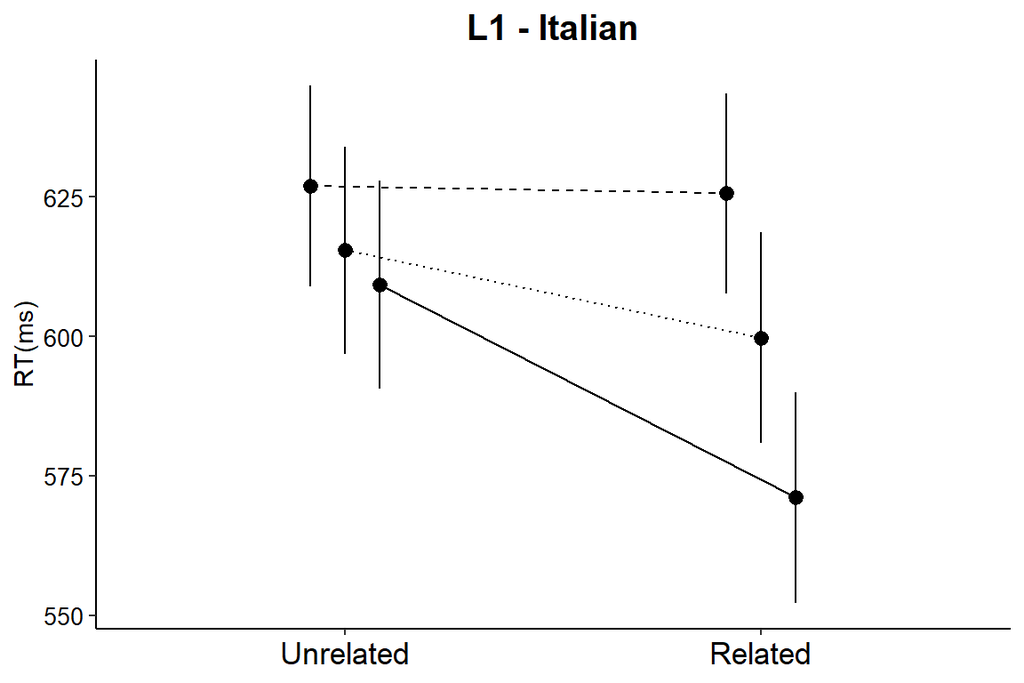

```r
df <- effect("relatedness:morphType",itaglmer2);
df <- as.data.frame(df);
revalue(df$relatedness, c("ctrl"="Unrelated"))-> df$relatedness;
revalue(df$relatedness, c("rel"="Related"))-> df$relatedness;

dodge1 <- position_dodge(width = 0.25);
bb  <-ggplot(data = df, aes(x = relatedness, y = fit,group = morphType)) +
  geom_point(size = 2, position = dodge1) +
  geom_line(aes(linetype=morphType), position = dodge1) +
  scale_linetype_manual(values=c("dashed", "dotted", "solid")) +
  theme_classic();
bb  <- bb + geom_pointrange(aes(ymin = df$lower, ymax = df$upper), position = dodge1) ;
bb  <- bb + scale_y_continuous("RT(ms)") ;
bb  <- bb + theme(axis.title.y = element_text(size = rel(1), angle = 90));
bb  <- bb + theme(axis.text.y = element_text(angle = 00, hjust = 1, size=10, colour = 'black'));
bb  <- bb + theme(axis.title.x = element_blank()) + theme(axis.text.x = element_text(size=13, colour = 'black'));
bb <- bb + labs(title='L1 - Italian');
bb <- bb + theme(plot.title= element_text(angle = 00, hjust=0.5, size=15, face = 'bold', colour = 'black'));
bb <- bb + theme(legend.position="none")
bb
```

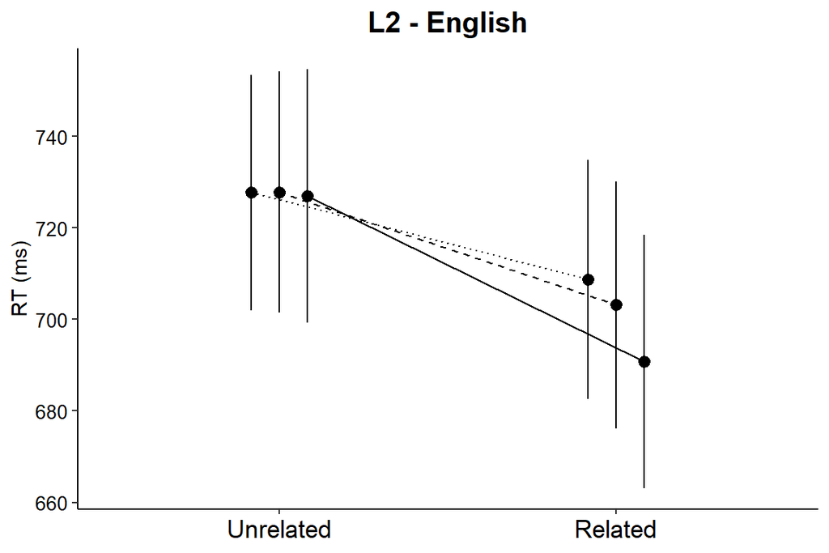

```r
df <- effect("relatedness:morphType",engglmer2);
df <- as.data.frame(df);
revalue(df$relatedness, c("ctrl"="Unrelated"))-> df$relatedness;
revalue(df$relatedness, c("rel"="Related"))-> df$relatedness;

dodge <- position_dodge(width = 0.25);
gg  <-ggplot(data = df, aes(x = relatedness, y = fit,group = morphType)) +
  geom_point(size = 2, position = dodge) +
  geom_line(aes(linetype=morphType), position = dodge) +
  scale_linetype_manual(values=c( "dotted", "dashed", "solid")) +
  theme_classic();
gg  <- gg + geom_pointrange(aes(ymin = df$lower, ymax = df$upper), position = dodge);
gg  <- gg + scale_y_continuous("RT (ms)") ;
gg  <- gg + theme(axis.text.y = element_text(angle = 00, hjust = 1, size=10, colour = 'black'));
gg  <- gg + theme(axis.title.x = element_blank()) + theme(axis.text.x = element_text(size=13, colour = 'black'));
gg <- gg + labs(title='L2 - English');
gg <- gg + theme(plot.title= element_text(angle = 00, hjust=0.5, size=15, face = 'bold', colour = 'black'));
gg<- gg + theme(legend.position="none")
gg
```

## Figure 2 - Participants’ score distributions for each proficiency subtest

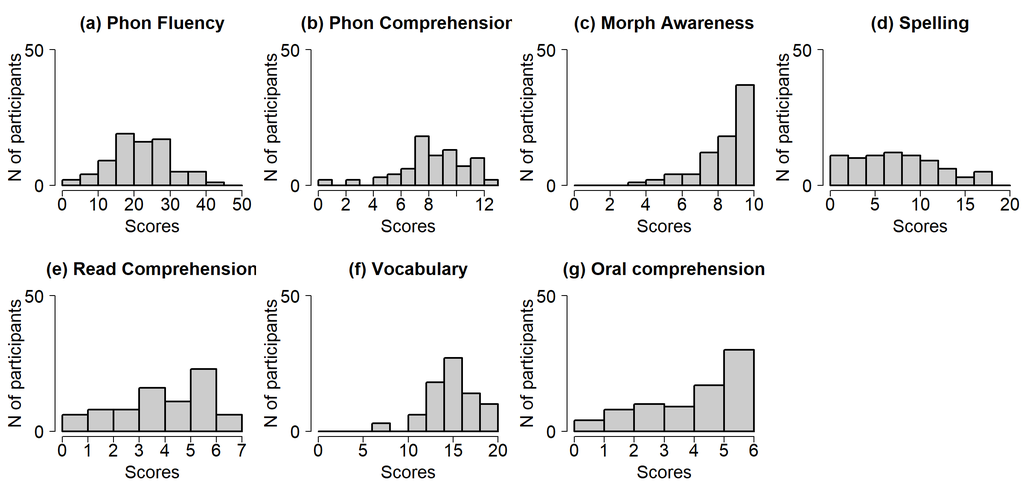

```r
par(mfrow=c(2,4));
par(mar=c(5,5,4,.5)+.1);
par(lwd=2);

attach(pptFeatures);

hist(phonemicFluency, breaks = seq(0,50,5), main = '(a) Phon Fluency', cex.main=2, xlab = 'Scores', ylab = 'N of participants', ylim=c(0,50), cex.lab=2, axes=F, col=grey(.80), border=grey(0));
axis(1, cex.axis=2);
axis(2, at=c(0,50), cex.axis=2, las=1);

hist(phonemicComprehension, breaks = seq(0,13,1), main = '(b) Phon Comprehension', cex.main=2, xlab = 'Scores', ylab = 'N of participants', ylim=c(0,50), cex.lab=2, axes=F, col=grey(.80), border=grey(0));
axis(1, cex.axis=2);
axis(2, at=c(0,50), cex.axis=2, las=1);

hist(morphComprehension, breaks = seq(0,10,1), main = '(c) Morph Awareness', cex.main=2, xlab = 'Scores', ylab = 'N of participants', ylim=c(0,50), cex.lab=2, axes=F, col=grey(.80), border=grey(0));
axis(1, cex.axis=2);
axis(2, at=c(0,50), cex.axis=2, las=1);

hist(spelling, breaks = seq(0,20,2), main = '(d) Spelling', cex.main=2, xlab = 'Scores', ylab = 'N of participants', ylim=c(0,50), cex.lab=2, axes=F, col=grey(.80), border=grey(0));
axis(1, cex.axis=2);
axis(2, at=c(0,50), cex.axis=2, las=1);

hist(readingComprehension, breaks = seq(0,7,1), main = '(e) Read Comprehension', cex.main=2, xlab = 'Scores', ylab = 'N of participants', ylim=c(0,50), cex.lab=2, axes=F, col=grey(.80), border=grey(0));
axis(1, cex.axis=2);
axis(2, at=c(0,50), cex.axis=2, las=1);

hist(vocabulary, breaks = seq(0,20,2), main = '(f) Vocabulary', cex.main=2, xlab = 'Scores', ylab = 'N of participants', ylim=c(0,50), cex.lab=2, axes=F, col=grey(.80), border=grey(0));
axis(1, cex.axis=2);
axis(2, at=c(0,50), cex.axis=2, las=1);

hist(oralComprehension, breaks = seq(0,6,1), main = '(g) Oral comprehension', cex.main=2, xlab = 'Scores', ylab = 'N of participants', ylim=c(0,50), cex.lab=2, axes=F, col=grey(.80), border=grey(0));
axis(1, cex.axis=2);
axis(2, at=c(0,50), cex.axis=2, las=1);
#dev.off()
detach(pptFeatures);
```

## Figure 3 - Interaction by phonemic comprehension by relatedness and morphtype

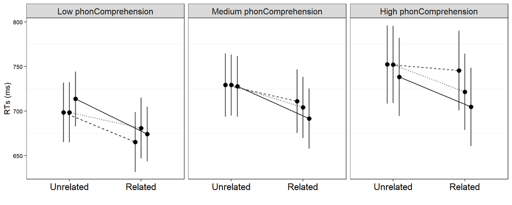

```r
temp <- data.frame(effect('relatedness:morphType:phonemicComprehension', proficiencyglmer2, se=list(level=.95), xlevels=list(phonemicComprehension=quantile(dataEng$phonemicComprehension, probs=c(.05,.50,.95)))));
revalue(temp$relatedness, c("rel"="Related"))-> temp$relatedness;
revalue(temp$relatedness, c("ctrl"="Unrelated"))-> temp$relatedness;

phonComprehension_names <- c(
  "5" = "Low phonComprehension",
  "9" = "Medium phonComprehension",
  "12" = "High phonComprehension");

ggplot(data = temp, aes(x=relatedness, y=fit, group=morphType)) +
  geom_point(size = 2, position = position_dodge(width = 0.25)) +
  geom_line(aes(linetype=morphType), position = position_dodge(width = 0.25)) +
  scale_linetype_manual(values=c("dashed", "dotted", "solid")) +
  theme_bw() +
  theme(panel.grid.major = element_blank()) +
  ylab('RTs (ms)') + xlab('') +
  theme(axis.text.y = element_text(angle = 00, hjust = 1, size=8, colour = 'black'))+
  theme(axis.text.x = element_text(size=13, colour = 'black'))+
  geom_pointrange(aes(ymin = lower, ymax = upper), position = position_dodge(width = 0.25)) +
  facet_grid(~ phonemicComprehension,
             labeller = labeller(phonemicComprehension = as_labeller(phonComprehension_names))) +
  theme(strip.text = element_text(size=12)) +
  theme(legend.position="none");
```

## Figure 4 - Interaction by morphological awareness/comprehension by relatedness and morphtype

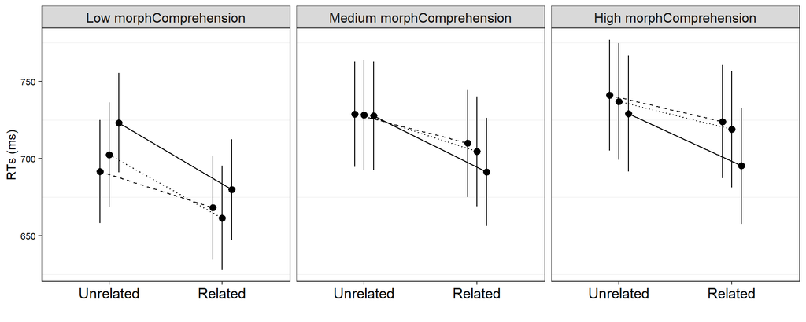

```r
temp <- data.frame(effect('relatedness:morphType:morphComprehension', proficiencyglmer3, se=list(level=.95), xlevels=list(morphComprehension=quantile(dataEng$morphComprehension, probs=c(.05,.50,.95)))));
revalue(temp$relatedness, c("rel"="Related"))-> temp$relatedness;
revalue(temp$relatedness, c("ctrl"="Unrelated"))-> temp$relatedness;

morphComprehension_names <- c(
  "6" = "Low morphComprehension",
  "9" = "Medium morphComprehension",
  "10" = "High morphComprehension");

ggplot(data = temp, aes(x=relatedness, y=fit, group=morphType)) +
  geom_point(size = 2, position = position_dodge(width = 0.25)) +
  geom_line(aes(linetype=morphType), position = position_dodge(width = 0.25)) +
  scale_linetype_manual(values=c("dashed", "dotted", "solid")) +
  theme_bw() +
  theme(panel.grid.major = element_blank()) +
  ylab('RTs (ms)') + xlab('') +
  theme(axis.text.y = element_text(angle = 00, hjust = 1, size=8, colour = 'black'))+
  theme(axis.text.x = element_text(size=13, colour = 'black'))+
  geom_pointrange(aes(ymin = lower, ymax = upper), position = position_dodge(width = 0.25)) +
  facet_grid(~ morphComprehension,
             labeller = labeller(morphComprehension = as_labeller(morphComprehension_names))) +
  theme(strip.text = element_text(size=12)) +
  theme(legend.position="none");
```

## Figure 5 - Interaction by vocabulary by relatedness and morphtype

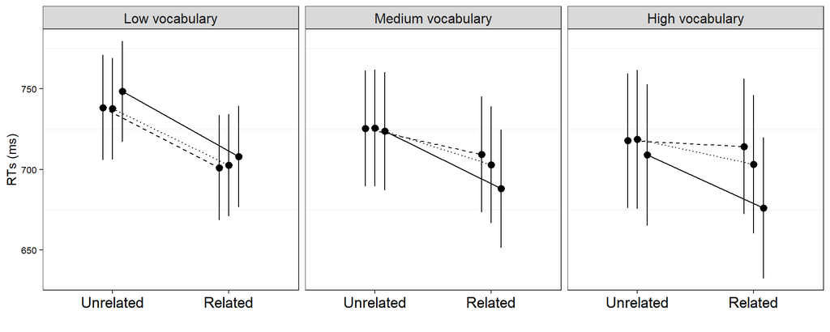

```r
temp <- data.frame(effect('relatedness:morphType:vocabulary', proficiencyglmer6, se=list(level=.95), xlevels=list(vocabulary=quantile(dataEng$vocabulary, probs=c(.05,.50,.95)))));
revalue(temp$relatedness, c("rel"="Related"))-> temp$relatedness;
revalue(temp$relatedness, c("ctrl"="Unrelated"))-> temp$relatedness;

vocabulary_names <- c(
  "11" = "Low vocabulary",
  "16" = "Medium vocabulary",
  "19" = "High vocabulary");

ggplot(data = temp, aes(x=relatedness, y=fit, group=morphType)) +
  geom_point(size = 2, position = position_dodge(width = 0.25)) +
  geom_line(aes(linetype=morphType), position = position_dodge(width = 0.25)) +
  scale_linetype_manual(values=c("dashed", "dotted", "solid")) +
  theme_bw() +
  theme(panel.grid.major = element_blank()) +
  ylab('RTs (ms)') + xlab('') +
  theme(axis.text.y = element_text(angle = 00, hjust = 1, size=8, colour = 'black'))+
  theme(axis.text.x = element_text(size=13, colour = 'black'))+
  geom_pointrange(aes(ymin = lower, ymax = upper), position = position_dodge(width = 0.25)) +
  facet_grid(~ vocabulary,
             labeller = labeller(vocabulary = as_labeller(vocabulary_names))) +
  theme(strip.text = element_text(size=12)) +
  theme(legend.position="none");
```

## Figure 6 - Interaction by phonemic Fluency by relatedness and morphtype

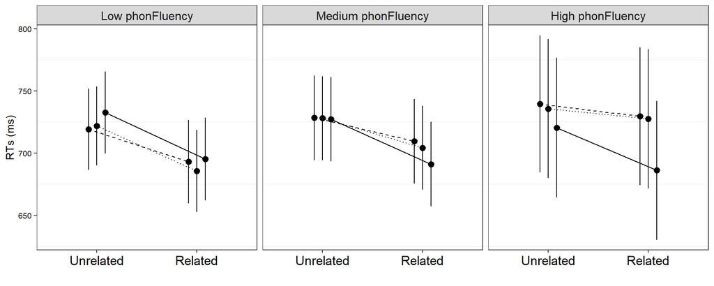

```r
temp <- data.frame(effect('relatedness:morphType:phonemicFluency', proficiencyglmer1, se=list(level=.95), xlevels=list(phonemicFluency=quantile(dataEng$phonemicFluency, probs=c(.05,.50,.95)))));
revalue(temp$relatedness, c("rel"="Related"))-> temp$relatedness;
revalue(temp$relatedness, c("ctrl"="Unrelated"))-> temp$relatedness;

phonemicFluency_names <- c(
  "10" = "Low phonFluency",
  "23" = "Medium phonFluency",
  "39" = "High phonFluency");

ggplot(data = temp, aes(x=relatedness, y=fit, group=morphType)) +
  geom_point(size = 2, position = position_dodge(width = 0.25)) +
  geom_line(aes(linetype=morphType), position = position_dodge(width = 0.25)) +
  scale_linetype_manual(values=c("dashed", "dotted", "solid")) +
  theme_bw() +
  theme(panel.grid.major = element_blank()) +
  ylab('RTs (ms)') + xlab('') +
  theme(axis.text.y = element_text(angle = 00, hjust = 1, size=8, colour = 'black'))+
  theme(axis.text.x = element_text(size=13, colour = 'black'))+
  geom_pointrange(aes(ymin = lower, ymax = upper), position = position_dodge(width = 0.25)) +
  facet_grid(~ phonemicFluency,
             labeller = labeller(phonemicFluency = as_labeller(phonemicFluency_names))) +
  theme(strip.text = element_text(size=12)) +
  theme(legend.position="none");
```

## Figure 7 - Scores distributions in the AoA questionnaire

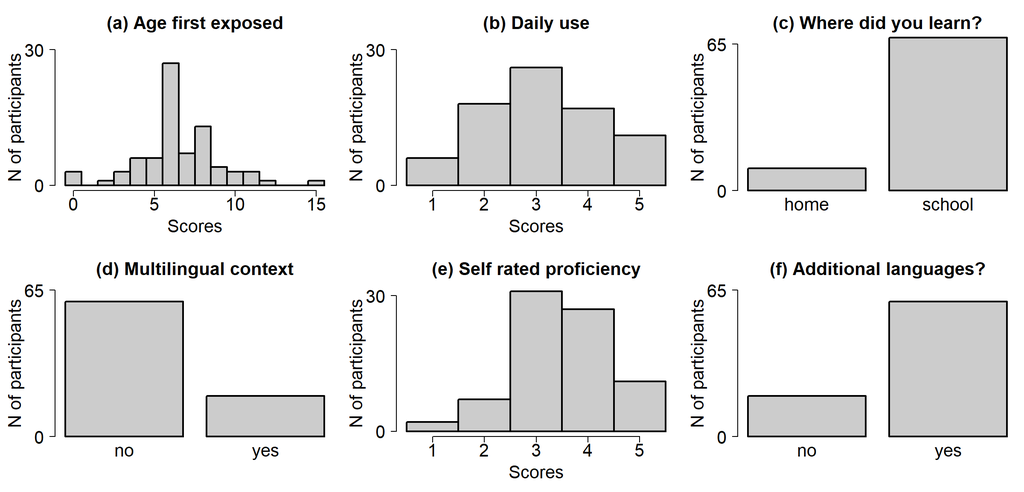

```r
#jpeg(filename = paste(localGitDir,'/aoaScores.jpg', sep = ''), res=300, height=2200, width=4400);
par(mfrow=c(2,3));
par(mar=c(5,5,4,.5)+.1);
par(lwd=2);

attach(pptFeatures);

hist(aoa1.Aoa, breaks = seq(-.5,15.5,1), main = '(a) Age first exposed', cex.main=2, xlab = 'Scores', ylab = 'N of participants', ylim=c(0,30), cex.lab=2, axes=F, col=grey(.80), border=grey(0));
axis(1, cex.axis=2);
axis(2, at=c(0,30), cex.axis=2, las=1);

hist(aoa2.usage, breaks = seq(.5,5.5,1), main = '(b) Daily use', cex.main=2, xlab = 'Scores', ylab = 'N of participants', ylim=c(0,30), cex.lab=2, axes=F, col=grey(.80), border=grey(0));
axis(1, cex.axis=2);
axis(2, at=c(0,30), cex.axis=2, las=1);

barplot(table(aoa3.context), main = '(c) Where did you learn?', cex.main=2,  ylab = 'N of participants', ylim=c(0,65), cex.lab=2, cex.names=2, axes=F, col=grey(.80), border=grey(0));
axis(2, at=c(0,65), cex.axis=2, las=1);

barplot(table(aoa4.contextMultling), main = '(d) Multilingual context', cex.main=2, ylab = 'N of participants', ylim=c(0,65), cex.lab=2, cex.names=2, axes=F, col=grey(.80), border=grey(0));
axis(2, at=c(0,65), cex.axis=2, las=1);

hist(aoa5.selfRatedProf, breaks = seq(.5,5.5,1), main = '(e) Self rated proficiency', cex.main=2, xlab = 'Scores', ylab = 'N of participants', ylim=c(0,30), cex.lab=2, axes=F, col=grey(.80), border=grey(0));
axis(1, cex.axis=2);
axis(2, at=c(0,30), cex.axis=2, las=1);

barplot(table(aoa6.otherLang), main = '(f) Additional languages?', cex.main=2, ylab = 'N of participants', ylim=c(0,65), cex.lab=2, cex.names=2, axes=F, col=grey(.80), border=grey(0));
axis(2, at=c(0,65), cex.axis=2, las=1);
```

```r
detach(pptFeatures);

par(mfrow=c(1,1));
#dev.off();
```

## Figure 8 - Interaction by AoA1 by relatedness and morphtype

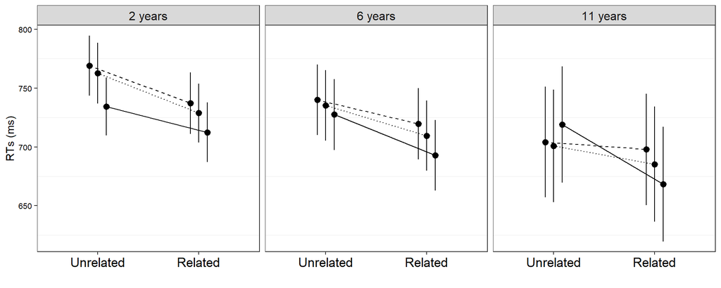

```r
temp <- data.frame(effect('relatedness:morphType:aoa1.Aoa', aoaglmer1, se=list(level=.95), xlevels=list(aoa1.Aoa=quantile(dataEng$aoa1.Aoa, probs=c(.05,.50,.95)))));
revalue(temp$relatedness, c("rel"="Related"))-> temp$relatedness;
revalue(temp$relatedness, c("ctrl"="Unrelated"))-> temp$relatedness;

aoa1.Aoa_names <- c(
  "2" = "2 years",
  "6" = "6 years",
  "11" = "11 years");

ggplot(data = temp, aes(x=relatedness, y=fit, group=morphType)) +
  geom_point(size = 2, position = position_dodge(width = 0.25)) +
  geom_line(aes(linetype=morphType), position = position_dodge(width = 0.25)) +
  scale_linetype_manual(values=c("dashed", "dotted", "solid")) +
  theme_bw() +
  theme(panel.grid.major = element_blank()) +
  ylab('RTs (ms)') + xlab('') +
  theme(axis.text.y = element_text(angle = 00, hjust = 1, size=8, colour = 'black'))+
  theme(axis.text.x = element_text(size=13, colour = 'black'))+
  geom_pointrange(aes(ymin = lower, ymax = upper), position = position_dodge(width = 0.25)) +
  facet_grid(~ aoa1.Aoa,
             labeller = labeller(aoa1.Aoa = as_labeller(aoa1.Aoa_names))) +
  theme(strip.text = element_text(size=12)) +
  theme(legend.position="none");
```

```r
#ggsave("aoa1.AoA.jpg", width = 7, height = 3, dpi = 300);
```

## Figure 9 - Interaction by AoA2 by relatedness and morphtype

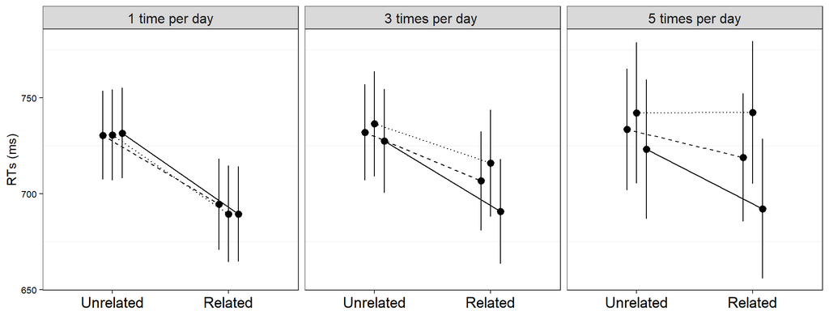

```r
temp <- data.frame(effect('relatedness:morphType:aoa2.usage', aoaglmer2c, se=list(level=.95), xlevels=list(aoa2.usage=quantile(dataEng$aoa2.usage, probs=c(.05,.50,.95)))));
revalue(temp$relatedness, c("rel"="Related"))-> temp$relatedness;
revalue(temp$relatedness, c("ctrl"="Unrelated"))-> temp$relatedness;

aoa2.usage_names <- c(
  "1" = "1 time per day",
  "3" = "3 times per day ",
  "5" = "5 times per day");

ggplot(data = temp, aes(x=relatedness, y=fit, group=morphType)) +
  geom_point(size = 2, position = position_dodge(width = 0.25)) +
  geom_line(aes(linetype=morphType), position = position_dodge(width = 0.25)) +
  scale_linetype_manual(values=c("dashed", "dotted", "solid")) +
  theme_bw() +
  theme(panel.grid.major = element_blank()) +
  ylab('RTs (ms)') + xlab('') +
  theme(axis.text.y = element_text(angle = 00, hjust = 1, size=8, colour = 'black'))+
  theme(axis.text.x = element_text(size=13, colour = 'black'))+
  geom_pointrange(aes(ymin = lower, ymax = upper), position = position_dodge(width = 0.25)) +
  facet_grid(~ aoa2.usage,
             labeller = labeller(aoa2.usage = as_labeller(aoa2.usage_names))) +
  theme(strip.text = element_text(size=12)) +
  theme(legend.position="none");
```

```r
#ggsave("aoa2.usage.jpg", width = 7, height = 3, dpi = 300);
```

## Figure 10 - Interaction by AoA5 by relatedness and morphtype

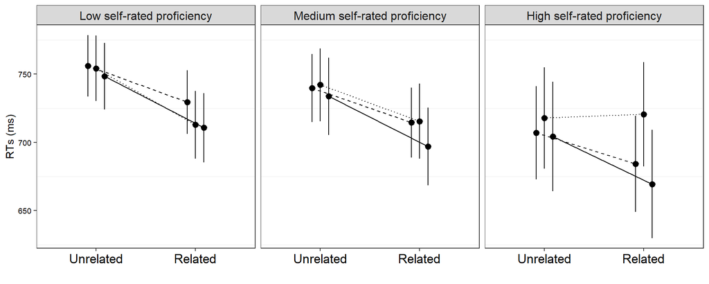

```r
temp <- data.frame(effect('relatedness:morphType:aoa5.selfRatedProf', aoaglmer5c, se=list(level=.95), xlevels=list(aoa5.selfRatedProf=quantile(dataEng$aoa5.selfRatedProf, probs=c(.05,.50,.95)))));
revalue(temp$relatedness, c("rel"="Related"))-> temp$relatedness;
revalue(temp$relatedness, c("ctrl"="Unrelated"))-> temp$relatedness;

aoa5.selfRatedProf_names <- c(
  "2" = "Low self-rated proficiency",
  "3" = "Medium self-rated proficiency",
  "5" = "High self-rated proficiency");

ggplot(data = temp, aes(x=relatedness, y=fit, group=morphType)) +
  geom_point(size = 2, position = position_dodge(width = 0.25)) +
  geom_line(aes(linetype=morphType), position = position_dodge(width = 0.25)) +
  scale_linetype_manual(values=c("dashed", "dotted", "solid")) +
  theme_bw() +
  theme(panel.grid.major = element_blank()) +
  ylab('RTs (ms)') + xlab('') +
  theme(axis.text.y = element_text(angle = 00, hjust = 1, size=8, colour = 'black'))+
  theme(axis.text.x = element_text(size=13, colour = 'black'))+
  geom_pointrange(aes(ymin = lower, ymax = upper), position = position_dodge(width = 0.25)) +
  facet_grid(~ aoa5.selfRatedProf,
             labeller = labeller(aoa5.selfRatedProf = as_labeller(aoa5.selfRatedProf_names))) +
  theme(strip.text = element_text(size=12)) +
  theme(legend.position="none");
```

```r
#ggsave("aoa5.selfratedProf.jpg", width = 7.5, height = 3, dpi = 300);
```

## Figure 11 - OSC by morphtype

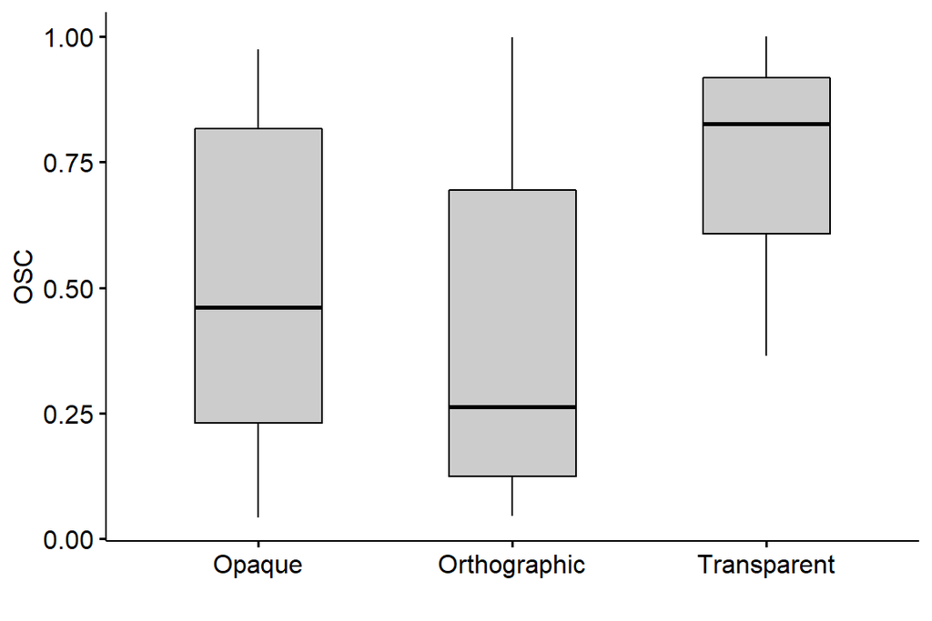

```r
temp <- unique(masterFile[masterFile$lexicality=='word' & masterFile$language=='eng',c('target','prime','morphType','relatedness','freqTarget','freqPrime','lengthTarget','lengthPrime','nTarget','nPrime','oscTarget')]);

revalue(temp$morphType, c("or"="Orthographic", 'op'='Opaque', 'tr'='Transparent'))-> temp$morphType;
library(ggpubr);
ggboxplot(subset(temp, oscTarget>0), "morphType", "oscTarget",
          color = "black", fill = grey(.80),
          width = 0.5, ylab = 'OSC', xlab = '');
```

## Figure 12 - OSC by phonemic fluency by relatedness

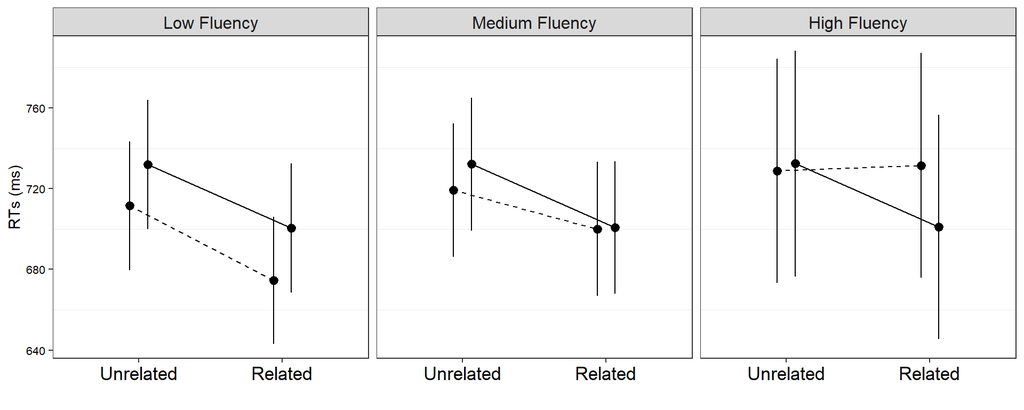

```r
temp <- data.frame(effect('relatedness:oscTarget:phonemicFluency', osc1, se=list(level=.95), xlevels=list(oscTarget=c(.20,.80), phonemicFluency=quantile(dataEng$phonemicFluency, probs=c(.05,.50,.95)))));
revalue(temp$relatedness, c("rel"="Related"))-> temp$relatedness;
revalue(temp$relatedness, c("ctrl"="Unrelated"))-> temp$relatedness;

phonemicFluency_names <- c(
  "10" = "Low Fluency",
  "23" = "Medium Fluency",
  "39" = "High Fluency"
);

temp$oscTarget <- as.factor(temp$oscTarget);
ggplot(data = temp, aes(x=relatedness, y=fit, group=oscTarget)) +
  geom_point(position = position_dodge(width = 0.25)) +
  geom_line(aes(linetype = oscTarget), position = position_dodge(width = 0.25)) +
  scale_linetype_manual(values=c("dashed", "solid")) +
  theme_bw() +
  theme(panel.grid.major = element_blank()) +
  ylab('RTs (ms)') + xlab('') +
  theme(axis.text.y = element_text(angle = 00, hjust = 1, size=8, colour = 'black'))+
  theme(axis.text.x = element_text(size=13, colour = 'black'))+
  geom_pointrange(aes(ymin = lower, ymax = upper), position = position_dodge(width = 0.25)) +
  facet_grid(~ phonemicFluency,
             labeller = labeller(phonemicFluency = as_labeller(phonemicFluency_names))) +
  theme(strip.text = element_text(size=12))+
  theme(legend.position="none");
```

```r
ggsave("oscModel.jpg", width = 7, height = 3, dpi = 300);
```

## Figure 13 - OSC by vocabulary by relatedness

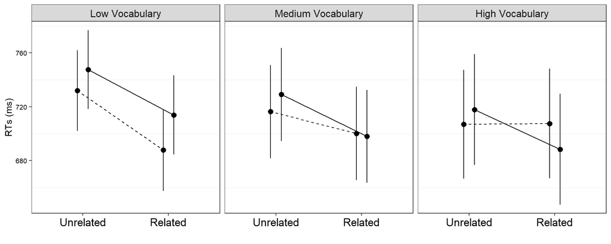

```r
temp <- data.frame(effect('relatedness:oscTarget:vocabulary', osc2, se=list(level=.95), xlevels=list(oscTarget=c(.20,.80), vocabulary=quantile(dataEng$vocabulary, probs=c(.05,.50,.95)))));
revalue(temp$relatedness, c("rel"="Related"))-> temp$relatedness;
revalue(temp$relatedness, c("ctrl"="Unrelated"))-> temp$relatedness;

vocabulary_names <- c(
  "11" = "Low Vocabulary",
  "16" = "Medium Vocabulary",
  "19" = "High Vocabulary"
);

temp$oscTarget <- as.factor(temp$oscTarget);
ggplot(data = temp, aes(x=relatedness, y=fit, group=oscTarget)) +
  geom_point(position = position_dodge(width = 0.25)) +
  geom_line(aes(linetype = oscTarget), position = position_dodge(width = 0.25)) +
  scale_linetype_manual(values=c("dashed", "solid")) +
  theme_bw() +
  theme(panel.grid.major = element_blank()) +
  ylab('RTs (ms)') + xlab('') +
  theme(axis.text.y = element_text(angle = 00, hjust = 1, size=8, colour = 'black'))+
  theme(axis.text.x = element_text(size=13, colour = 'black'))+
  geom_pointrange(aes(ymin = lower, ymax = upper), position = position_dodge(width = 0.25)) +
  facet_grid(~ vocabulary,
             labeller = labeller(vocabulary = as_labeller(vocabulary_names))) +
  theme(strip.text = element_text(size=12))+
  theme(legend.position="none");
```

```r
ggsave("vocabulary.jpg", width = 7.5, height = 3, dpi = 300);
```

## Figure 14 - morphComprehension by relatedness

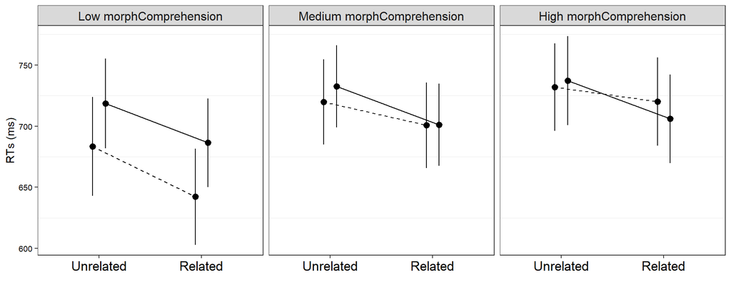

```r
temp <- data.frame(effect('relatedness:oscTarget:morphComprehension', osc4, se=list(level=.95), xlevels=list(oscTarget=c(.20,.80), morphComprehension=quantile(dataEng$morphComprehension, probs=c(.05,.50,.95)))));
revalue(temp$relatedness, c("rel"="Related"))-> temp$relatedness;
revalue(temp$relatedness, c("ctrl"="Unrelated"))-> temp$relatedness;

morphComprehension_names <- c(
  "6" = "Low morphComprehension",
  "9" = "Medium morphComprehension",
  "10" = "High morphComprehension"
);

temp$oscTarget <- as.factor(temp$oscTarget);
ggplot(data = temp, aes(x=relatedness, y=fit, group=oscTarget)) +
  geom_point(position = position_dodge(width = 0.25)) +
  geom_line(aes(linetype = oscTarget), position = position_dodge(width = 0.25)) +
  scale_linetype_manual(values=c("dashed", "solid")) +
  theme_bw() +
  theme(panel.grid.major = element_blank()) +
  ylab('RTs (ms)') + xlab('') +
  theme(axis.text.y = element_text(angle = 00, hjust = 1, size=8, colour = 'black'))+
  theme(axis.text.x = element_text(size=13, colour = 'black'))+
  geom_pointrange(aes(ymin = lower, ymax = upper), position = position_dodge(width = 0.25)) +
  facet_grid(~ morphComprehension,
             labeller = labeller(morphComprehension = as_labeller(morphComprehension_names))) +
  theme(strip.text = element_text(size=12))+
  theme(legend.position="none");
```

```r
ggsave("figure14.jpg", width = 7.7, height = 3, dpi = 300);
```